# Graficzna analiza struktury lasów losowych za pomocą pakietu ggRandomForests

Ola Paluszynska

9 stycznia 2017

## Wstęp

**Cel prezentacji:** demonstracja wykorzystania pakietu `ggRandomForests` do wizualizacji lasów losowych.

**Uwaga:** Pakiet `ggRandomForests` służy do wizualizacji lasów losowych stworzonych za pomocą pakietu `randomForestSRC`. Choć wiele wykresów tworzonych przez nowy pakiet można otrzymać przy pomocy `randomForestSRC`, to korzystanie z `ggRandomForests` daje trzy (?) udogodnienia:

- wykresy powstają przy użyciu `ggplot2`, przy czym można je łatwo modyfikować, gdyż funkcje zwracają obiekty klasy `ggplot`,
- otrzymane dane/wykresy stanowią samodzielne obiekty, co pozwala na łatwą modyfikację,
- rozdzielenie danych od wykresów: pakiet dostarcza funkcji operujących na obiektach powstałych przy pomocy `randomForestSRC` i zwracających dane, które później można przekształcić na wykresy za pomocą innych funkcji z `ggRandomForests`.

**Przypomnienie:** lasy losowe to modyfikacja baggingu, czyli agregacji wyniku zbioru drzew dla ustalonej liczby próbek bootstrapowych, polegająca na “uniezależnieniu” od siebie drzew z tego zbioru poprzez rozpatrywanie przy każdym podziale drzewa jednynie $m\leq p$ zmiennych wylosowanych spośród $p$ wszystkich zmiennych.

**Plan:** prześledzimy przykład dla regresji zaprezentowany przez autora pakietu w jego vignette (Ehrling, 2015), bardziej szczegółowo omawiając miary prezentowane przez poszczególne wykresy i idee za nimi idące.

## Dane

Będziemy korzystać ze zbioru danych “Boston” dotyczącego mieszkań w obszarach Bostonu, dostępnego m.in. w pakiecie `MASS`. Naszym celem jest stwierdzenie co i w jaki sposób wpływa na medianę ceny mieszkań w obszarze, przy czym zbiór zawiera następujące zmienne:

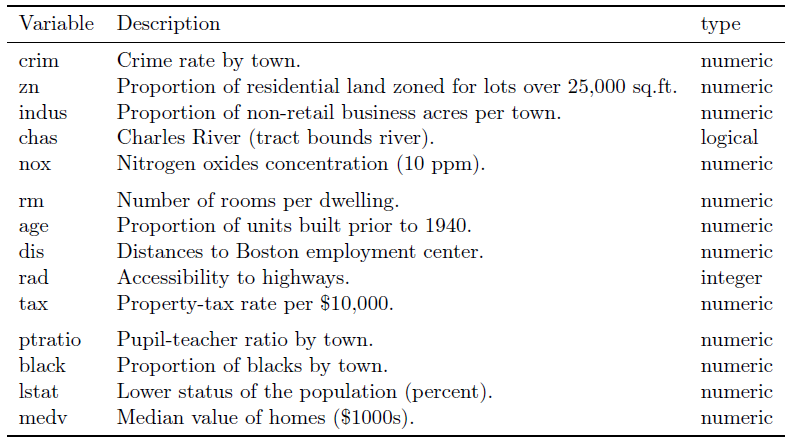

W celu stwierdzenia, które zmienne powinny wyjść “istotne” w naszej analizie rysujemy wykres każdej zmiennej ciągłej względem `medv` czyli tej, którą chcemy prognozować.

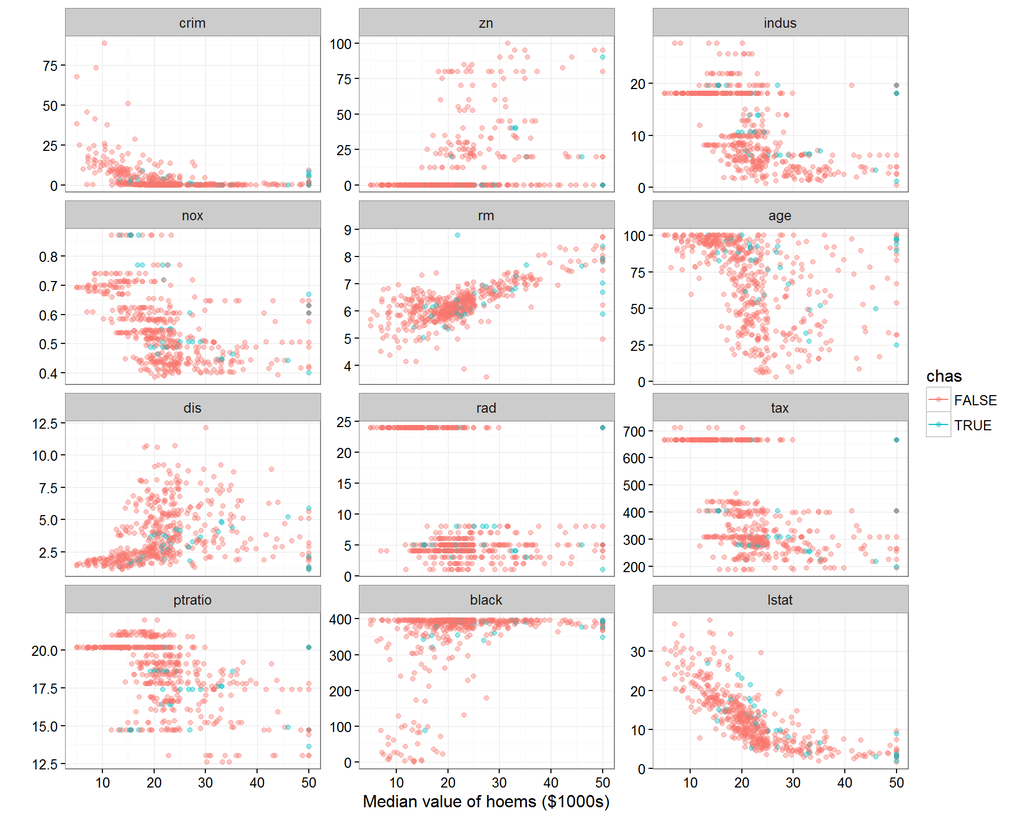

```r
data(Boston, package="MASS")
Boston$chas <- as.logical(Boston$chas)
dta <- melt(Boston, id.vars=c("medv","chas"))
ggplot(dta, aes(x=medv, y=value, color=chas))+ geom_point(alpha=.4)+ geom_rug(data=dta %>% filter(is.na(value)))+ labs(y="", x="Median value of hoems ($1000s)")+ facet_wrap(~variable, scales="free_y", ncol=3)
```

Budujemy las:

```r
rfsrc_Boston <- rfsrc(medv~., data = Boston, tree.err = TRUE, importance = "permute")
varsel_Boston <- var.select(rfsrc_Boston)
```

```
## minimal depth variable selection ...
##
##
## -----------------------------------------------------------
## family             : regr
## var. selection     : Minimal Depth
## conservativeness   : medium
## x-weighting used?  : TRUE
## dimension          : 13
## sample size        : 506
## ntree              : 1000
## nsplit             : 0
## mtry               : 5
## nodesize           : 5
## refitted forest    : FALSE
## model size         : 11
## depth threshold    : 6.749
## PE (true OOB)      : 10.8297
##
##
## Top variables:
##         depth   vimp
## rm      1.168 37.523
## lstat   1.196 57.394
## crim    2.463  8.406
## dis     2.596  5.307
## nox     2.618  8.195
## ptratio 2.945  5.830
## age     3.555  3.355
## tax     3.659  3.539
## indus   3.680  5.474
## black   3.769  1.116
## rad     6.251  1.216
## -----------------------------------------------------------
```

```r
rfsrc_Boston
```

```
##                          Sample size: 506
##                      Number of trees: 1000
##           Minimum terminal node size: 5
##        Average no. of terminal nodes: 104.156
## No. of variables tried at each split: 5
##               Total no. of variables: 13
##                             Analysis: RF-R
##                               Family: regr
##                       Splitting rule: mse
##                 % variance explained: 87.2
##                           Error rate: 10.83
```

## Błąd prognozy Out-of-Bag

**Próbka Out-of-Bag (OOB):** dla każdej obserwacji wyznaczamy jej prognozę z lasu biorąc pod uwagę tylko te drzewa, które uczono na próbce bez tej obserwacji. (Każda próbka bootstrapowa zawiera około 63.2% obserwacji).

**Błąd prognozy OOB** jest praktycznie taki sam, jak błąd obliczony za pomocą $n$-krotnej cross-walidacji, czyli w jednym kroku otrzymujemy zarówno las jak i oszacowanie błędu na zbiorze testowym.

Błąd ten jest liczony dla każdego drzewa przy budowie lasu (opcja `tree.err = TRUE` funkcji `rfsrc()`) i można go łatwo narysować za pomocą funkcji `plot.gg_error()`, która właściwie tylko wrzuca to do ggplota.

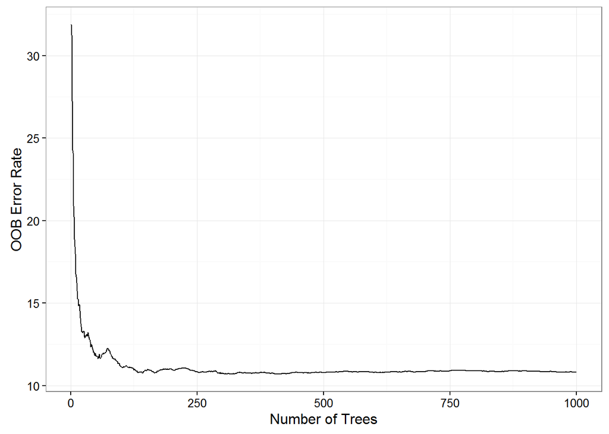

```r
gg_e <- gg_error(rfsrc_Boston)
plot(gg_e)
```

**Wniosek:** Jak widać błąd OOB w tym przypadku stabilizuje się już przy 250 drzewach, ale dla celów analizy ważnych zmiennych lepiej jest mieć ich więcej, żeby każda zmienna była uwzględniona w dostatecznej ich ilości.

## Prognoza lasu losowego

Funkcja `gg_rfsrc()` zwraca prognozy lasu (domyślnie OOB, mogą być też zwykłe), które można przedstawić na wykresie, choć to nie jest zbyt ciekawe…

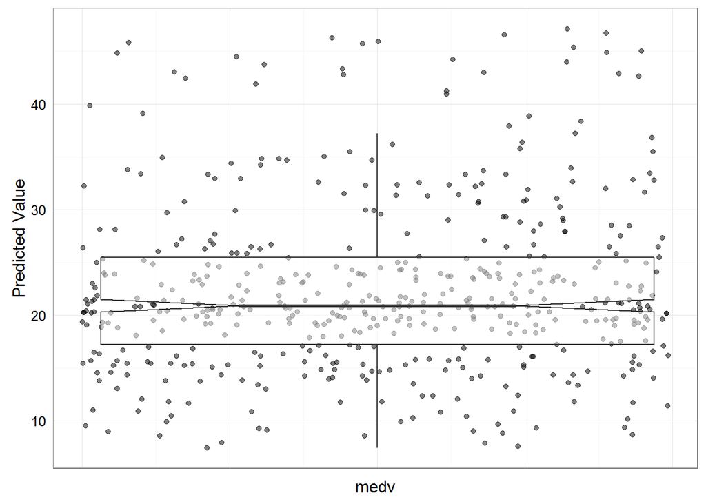

```r
plot(gg_rfsrc(rfsrc_Boston), alpha=.5)
```

## Ważność zmiennych

**Problem:** ponieważ las losowy nie zakłada żadnej postaci funkcyjnej nie daje też możliwości testowania istotności zmiennych. Warto pamiętać, że to jest zarazem największa zaleta lasu (drzew), gdyż pozwala na dowolną nieliniowość zależności między zmiennymi.

**Co można zrobić?** Analizować strukturę lasu, czyli drzew wchodzących w jego skład. Ponieważ jest ich dużo wszelkie miary muszą być łatwe w agregacji. Dwa podstawowe podejścia, to:

- *Variable importance* (VIMP) opiera się na pomyśle, że jeśli zmienna jest ważna, to jej zakłócenie powinno zwiększyć błąd predykcji.
- *Minimal depth* opiera się na pomyśle, że ważne zmienne występują w drzewie blisko korzenia, ponieważ wtedy na podstawie ich wartości dzielona jest duża część populacji.

### Variable importance

**VIMP** liczymy porównując błąd predykcji OOB przed i po zakłóceniu danej zmiennej.

**Jak zakłócać zmienne?**

- permutacja zmiennej (`permute`)
- predykcja OOB jest wyznaczana losowo na węzłach dzielących populację ze względu na wartości danej zmiennej (`random`)
- “$x$ is assigned to the opposite node whenever a split on $x$ is encountered in the in-bag tree” (`anti`)

Funkcja `vimp()` z pakietu `randomForestSRC` liczy VIMP według wybranej metody zakłócania (do wyboru: `"permute", "random", "anti", "permute.ensemble", "random.ensemble", "anti.ensemble"`, opcje z ensemble są szybsze). W nowym pakiecie dostajemy to za pomocą `plot.gg_vimp()`, która tworzy wykres ggplot:

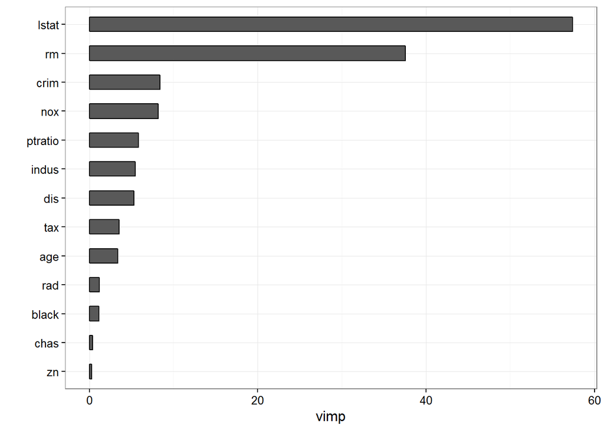

```r
plot(gg_vimp(rfsrc_Boston, importance = "permute"))
```

**Uwaga:** VIMP może być ujemne - oznacza to, że szum jest bardziej informatywny od danej zmiennej. Nie ma żadnej referencyjnej wartości VIMP, do której można by porównywać otrzymane żeby stwierdzić czy są “wystarczająco duże”.

### Minimal depth

Węzły w drzewie numerujemy od 0 (korzeń), czyli według ich odległości od korzenia. *Minimal depth* to średnia odległość od korzenia pierwszych węzłów dzielących populację według wybranej zmiennej, więc mniejsze wartości tej miary wskazują na zmienne częściej biorące udział w dzieleniu znacznej części populacji, czyli mające większy wpływ na sortowanie obserwacji.

Pakiet `randomForestSRC` dostarcza rankingu zmiennych pod względem minimal depth (funkcja `var.select()`), które oblicza znajdując maksymalne poddrzewa względem każdej ze zmiennych, czyli poddrzewa z korzeniem dzielącym próbę ze względu na tę zmienną.

Nowy pakiet zamienia wynik `var.select()` na ramkę danych (funkcja `gg_minimal_depth()`) i tworzy wykres ggplot za pomocą `plot()`.

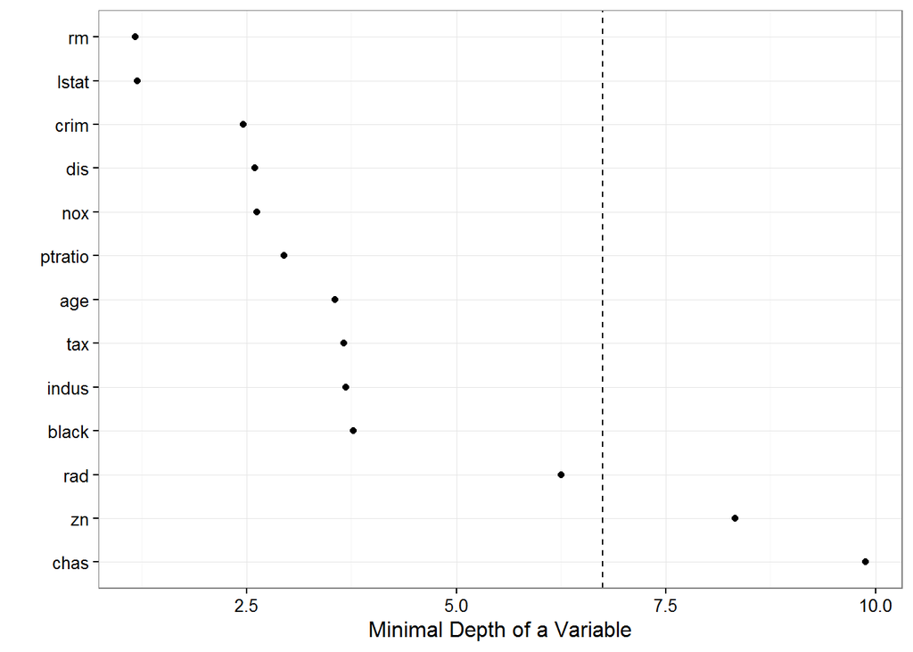

```r
gg_md <- gg_minimal_depth(varsel_Boston)
plot(gg_md)
```

W przeciwieństwie do VIMP, dla minimal depth można wyznaczyć wartość progową (pionowa linia przerywana), do której porównuje się pozostałe wartości, żeby stwierdzić, czy są duże, czy nie. W tym przypadku wzięto średnią z rozkładu minimal depth.

Za pomocą `plot.gg_minimal_vimp()` można porównać pozycję zmiennych w rankingu VIMP oraz minimal depth:

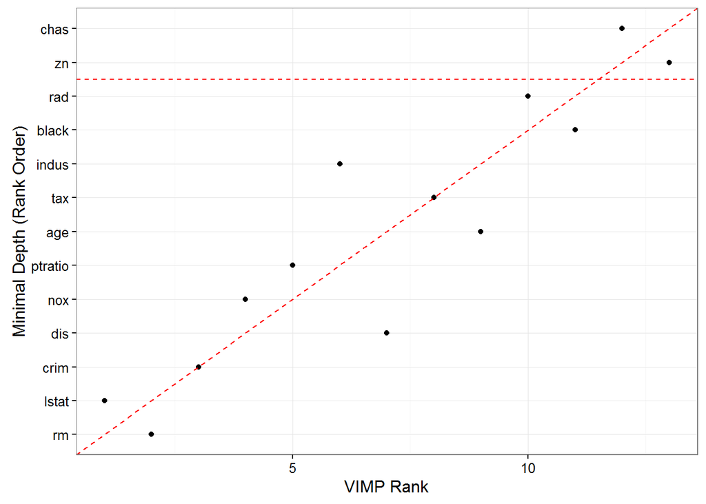

```r
plot(gg_minimal_vimp(gg_md))
```

### Maksymalne poddrzewa

Ishwaran et al. (2010) wprowadzają pojęcie maksymalnych poddrzew dla zmiennej $v$:

**Definicja:** Dla każdej zmiennej $v$, $T_v$ nazywamy $v$-poddrzewem $T$ jeśli korzeń $T_v$ jest dzielony względem zmiennej $v$. $T_v$ nazywamy maksymalnym $v$-poddrzewem jeśli $T_v$ nie jest poddrzewem żadnego większego $v$-drzewa.

**Uwaga:** maksymalne $v$-poddrzewo może nie istnieć lub może ich być kilka.

Maksymalne poddrzewa są wartościową koncepcją, ponieważ:

- pozwalają mierzyć ważność zmiennej - rzadko zdarza się, że mało informatywne zmienne stanowią kryterium podziału węzłów blisko korzenia, więc to znika przy uśrednianiu,
- można za ich pomocą identyfikować ważne interakcje zmiennych, np. poprzez analizę $(v,w)$-maksymalnych poddrzew, czyli maksymalnych $w$-poddrzew wewnątrz maksymalnych $v$-poddrzew,
- dotyczą wyłącznie struktury drzewa (np. zasad podziału), nie są związane z błędem predykcji, który nie zawsze jest najważniejszy w analizie (np. w analizie przeżycia nie jest jasne co jest dobrą miarą błędu predykcji),
- w przeciwieństwie do VIMP, które opierają się na losowaniu, maksymalne poddrzewa można dokładnie analizować.

**Definicja:** Niech $D_v$ będzie odległością od korzenia całego drzewa do korzenia najbliższego maksymalnego $v$-poddrzewa dla ustalonego $v$. Wtedy $D_v$ jest nieujemną zmienną losową przyjmującą wartości ze zbioru $\{0,\ldots,D(T)\}$, gdzie $D(T)$ jest wysokością drzewa. $D_v$ to *minimal depth* $v$.

**Twierdzenie:** Niech $D(T)\geq 1$ będzie ustalone, a liczba węzłów o głębokości d, $l_d$, wynosi $2^d$. Załóżmy, że $\pi_{v,j}(t)$ i $\theta_{v,j}(t)$ zależą jedynie od głębokości węzła $t$, wtedy:
$$\mathbb{P}(D_v=d)= \left[\prod_{j=0}^{d-1}(1-\pi_{v,j}\theta_{v,j})^{l_j}\right][1- (1-\pi_{v,d}\theta_{v,d})^{l_d}],\quad 0\leq d\leq D(T)-1,$$

gdzie:

- $\pi_{v,j}(t)$ oznacza prawdopodobieństwo, że $v$ jest kandydatką (jedną z $m\leq p$) do podziału na węźle $t$ o głębokości $j$ przy założeniu, że nie istnieje maksymalne $v$-poddrzewo na głębokości mniejszej niż $j$,
- $\theta_{v,j}(t)$ oznacza prawdopodobieństwo, że $v$ dzieli węzeł $t$ o głębokości $j$ przy założeniu, że $v$ jest kandydatką do podziału na węźle $t$ oraz nie istnieje maksymalne $v$-poddrzewo na głębokości mniejszej niż $j$.

*Dowód:* Z definicji $\pi_{v,j}$ i $\theta_{v,j}$ jeśli $t$ jest węzłem o głębokości $j\leq d$, to
$$\mathbb{P}(v \text{ nie dzieli } t|D_v\geq j)=1-\pi_{v,j}\theta_{v,j}.$$

Ponadto, $\mathbb{P}(D_v=0)=\pi_{v,0}\theta_{v,0}$. Stąd, prawdopodobieństwo, że nie istnieje maksymalne $v$-poddrzewo na głębokości mniejszej niż $d\geq 1$ wynosi
$$\mathbb{P}(D_v\geq d)=\mathbb{P}(D_v\geq 1) \prod_{j=1}^{d-1} \mathbb{P}(v\text{ nie dzieli na głębokości } j|D_v\geq j)=$$
$$=[1-\mathbb{P}(D_v=0)]\prod_{j=1}^{d-1} \mathbb{P}(v\text{ nie dzieli na głębokości } j|D_v\geq j) = \prod_{j=0}^{d-1} \mathbb{P}(1-\pi_{v,j}\theta_{v,j})^{l_j},$$
gdzie $l_j=2^j$ jest równe całkowitej liczbie węzłów na głębokości $j$. Ponieważ $D_v\geq d$, prawdopodobieństwo, że $v$ dzieli węzeł na głębokości $d$ wynosi 1 minus prawdopodobieństwo, że każdy węzeł na głębokości $d$ dzielony jest inną zmienną niż $v$ czyli $1-(1-\pi_{v,d}\theta_{v,d})^{l_d}$.

Ostateczny wynik dostajemy ze wzoru
$$\mathbb{P}(D_v=d)=\mathbb{P}(v\text{ dzieli na głębokości } d|D_v\geq d)\cdot \mathbb{P}(D_v\geq d).$$

## Zależność między prognozą i zmiennymi

VIMP i minimal depth mogą być podstawą do wyboru mniejszego podzbioru z rozpatrywanych zmiennych. W tym celu chcemy zbadać jak poszczególne zmienne wpływają na predykcję lasu.

**Uwaga:** choć las losowy jest często nazywany “czarną skrzynką”, to jego prognoza jest przecież (skomplikowaną) funkcją rozważanych zmiennych:
$$\hat{f}_{rf}=f(x).$$
Do analizy powyższej zależności najlepiej wykorzystać metody graficzne.

### Variable dependence

Wykresy **variable dependence** pokazują zależność prognozy od określonej zmiennej. Każdy punkt na wykresie to jedna obserwacja, a ponieważ wartość prognozy jest zależna od wszystkich zmiennych jednocześnie, to interpretację wykresu należy przeprowadzać z uwagą.

Funkcja `gg_variable()` wyciąga zmienne wykorzystane do uczenia lasu oraz prognozę OOB z lasu oraz obiektu typu `predict` z pakietu `randomForestSRC`. Natępnie, funkcja `plot.gg_variable()` zwraca listę wykresów `ggplot` dla zmiennych zadeklarowanych jako `xvar` lub jeden wykres jeśli wybrano opcję `panel=TRUE`.

W naszym przykładzie dla 10 zmiennych o najniższym minimal depth dostajemy:

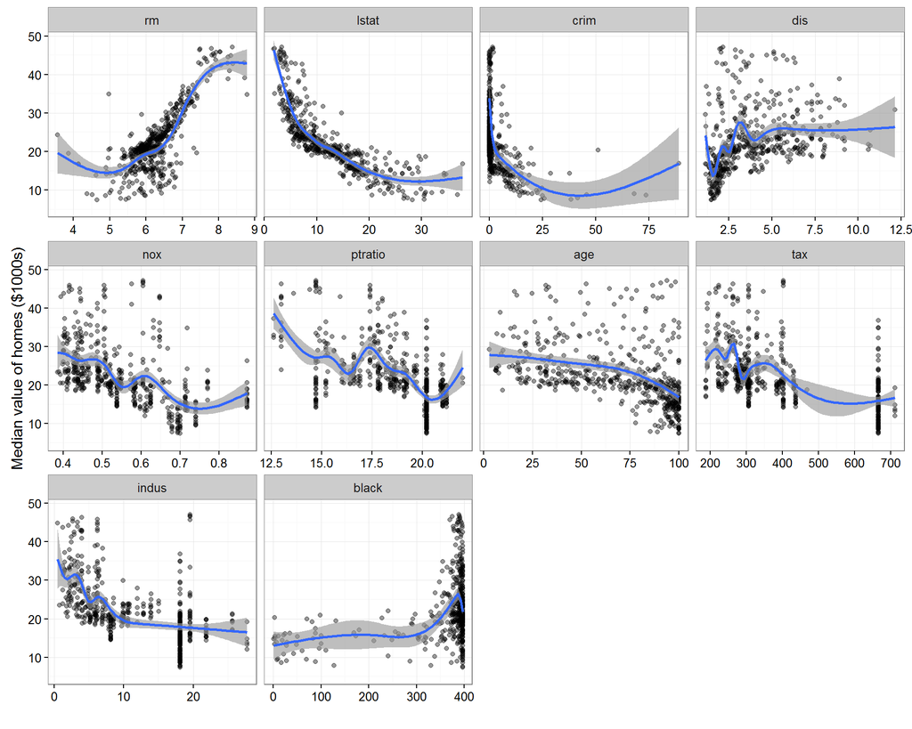

```r
gg_v <- gg_variable(rfsrc_Boston)
xvar <- gg_md$topvars[1:10]
plot(gg_v, xvar=xvar, panel=TRUE, alpha=.4)+geom_smooth(se=TRUE, level=.95, span=1.2)+ labs(y="Median value of homes ($1000s)", x="")
```

Jak widać, wykresy te są podobne do tych, które otrzymaliśmy na początku przy eksploracji danych, czego można się spodziewać jeśli dany las losowy dobrze prognozuje.

**Uwaga:** dla zmiennych jakościowych odpowiednim wykresem jest boxplot, stąd dla nich rysujemy osobny wykres (w tym przypadku mamy tylko jedną taką zmienną, w dodatku mało ważną według wszelkich miar).

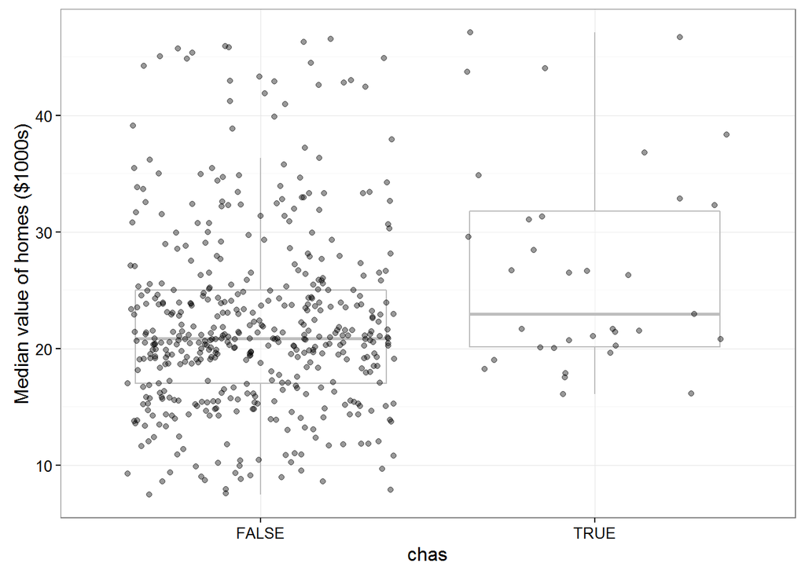

```r
plot(gg_v, xvar="chas", points=FALSE, alpha=.4)+ geom_boxplot(notch=TRUE, na.rm=TRUE)+ labs(y="Median value of homes ($1000s)")
```

### Partial dependence

Wykresy **partial dependence** pokazują zależność predykcji od określonej zmiennej po wyłączniu zależności od pozostałych zmiennych, co liczy się następująco: dla wybranej zmiennej $x$ wybierane są równoodległe punkty wzdłuż jej rozkładu, aby następnie dla każdego z nich obliczyć średnią predykcję lasu dla wszystkich pozostałych zmiennych, czyli:
$$\tilde{f}(x)=\frac{1}{n}\sum_{i=1}^n \hat{f}(x,x_{i,o}),$$
gdzie $\hat{f}$ jest prognozą lasu, a $x_{i,o}$ to wartości wszystkich zmiennych poza $x$ dla obserwacji $i$.

**Idea:** uśredniamy predykcje każdej obserwacji ze zbioru uczącego dla każdej z wybranego zbioru wartości $X=x$.

Funkcja `gg_partial()` tworzy listę obiektów (po jednym dla każdej zmiennej) korzystając z wyniku funkcji `plot.variable()` z pakietu `randomForestSRC`, co następnie można narysować korzystając z `plot.gg_partial()`.

**Uwaga:** wykresy cząstkowe są znacznie bardziej wymagające obliczeniowo, co należy mieć na uwadze wybierając liczbę punktów z rozkładu każdej ze zmiennych, które mają być rozpatrzone (opcja `npts` funkcji `plot.variable()`).

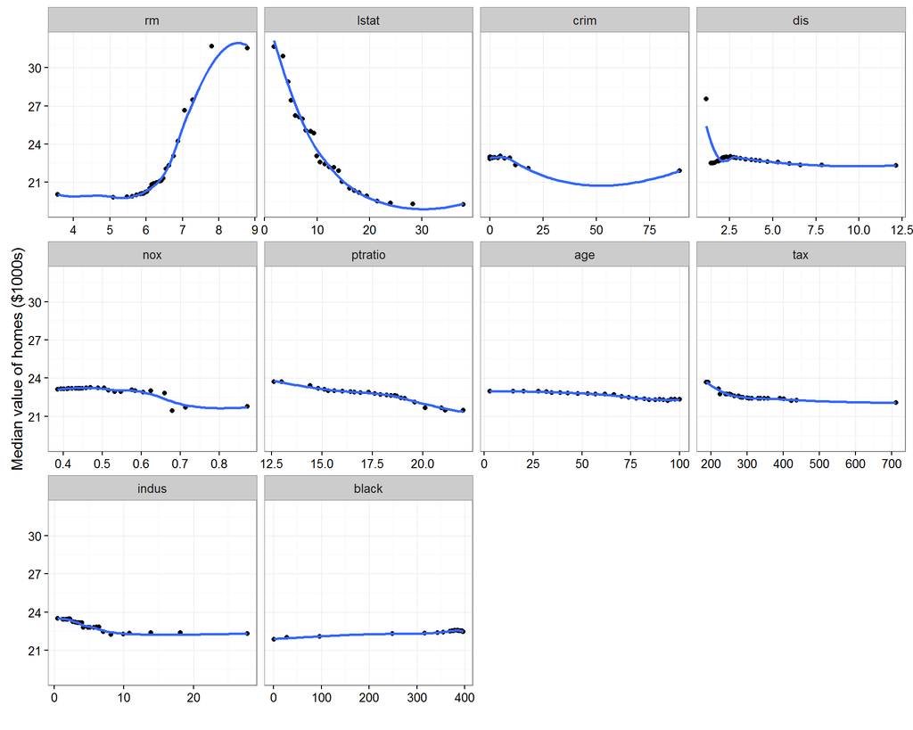

```r
partial_Boston <- plot.variable(rfsrc_Boston, xvar=xvar, partial=TRUE, sorted=FALSE, show.plots = FALSE)
gg_p <- gg_partial(partial_Boston)
plot(gg_p, panel=TRUE)+ labs(y="Median value of homes ($1000s)", x="") + geom_smooth(se=FALSE)
```

**Wniosek:** teraz wyraźnie widać, że zmienne *lstat* i *rm* odgrywają dużo większą rolę w prognozowaniu niż pozostałe zmienne (patrz: płaskie wykresy); jest to zależność nieliniowa!

## Analiza interakcji

### Interakcje minimal depth

Najbardziej podstawowa koncepcja analizy struktury lasów, *minimal depth*, pozwala również analizować interakcje między zmiennymi. Zamiast $v$-maksymalnych poddrzew wystarczy rozpatrywać $(v,w)$-maksymalne poddrzewa, czyli maksymalne $w$-poddrzewa wewnątrz maksymalnych $v$-poddrzew.

Funkcja `randomForestSRC::find.interaction` dostarcza macierzy $p\times p$ z uogólnioną miarą *minimal depth* (opcja `method="maxsubtree"`) dla każdej pary zmiennych, przy czym:

- wyrazy na diagonali $(i,i)$ to unormowane względem korzenia (wielkości drzewa) minimal depth zmiennej $i$,
- wyrazy poza diagonalą $(i,j)$ to minimal depth zmiennej $j$ względem maksymalnego $i$-poddrzewa unormowane względem rozmiaru tego maksymalnego poddrzewa.

W nowym pakiecie funkcja `plot.gg_interaction()` daje odpowiedni wykres:

```r
interaction_Boston <- find.interaction(rfsrc_Boston, method = "maxsubtree", sorted = TRUE)
```

```
##
##                               Method: maxsubtree
##                     No. of variables: 13
##   Variables sorted by minimal depth?: TRUE
##
##           rm lstat crim  dis  nox ptratio  age  tax indus black  rad   zn
## rm      0.08  0.15 0.20 0.19 0.23    0.25 0.23 0.25  0.31  0.25 0.43 0.57
## lstat   0.15  0.08 0.18 0.16 0.20    0.26 0.22 0.25  0.30  0.24 0.44 0.59
## crim    0.25  0.21 0.16 0.26 0.32    0.47 0.29 0.48  0.49  0.32 0.63 0.78
## dis     0.21  0.21 0.28 0.17 0.33    0.38 0.27 0.38  0.41  0.31 0.57 0.72
## nox     0.29  0.25 0.27 0.29 0.17    0.51 0.34 0.50  0.54  0.36 0.66 0.79
## ptratio 0.26  0.27 0.34 0.33 0.43    0.19 0.33 0.43  0.47  0.38 0.62 0.73
## age     0.27  0.29 0.31 0.32 0.41    0.45 0.23 0.45  0.44  0.36 0.65 0.78
## tax     0.32  0.36 0.42 0.40 0.50    0.51 0.41 0.24  0.54  0.46 0.66 0.75
## indus   0.35  0.36 0.43 0.41 0.51    0.52 0.41 0.53  0.24  0.46 0.67 0.77
## black   0.37  0.34 0.39 0.39 0.52    0.59 0.39 0.61  0.58  0.24 0.73 0.87
## rad     0.62  0.65 0.69 0.69 0.79    0.77 0.68 0.77  0.79  0.72 0.40 0.91
## zn      0.80  0.84 0.84 0.84 0.90    0.88 0.83 0.88  0.89  0.85 0.93 0.54
## chas    0.82  0.80 0.83 0.83 0.88    0.91 0.83 0.91  0.92  0.85 0.94 0.98
##         chas
## rm      0.71
## lstat   0.68
## crim    0.79
## dis     0.81
## nox     0.82
## ptratio 0.85
## age     0.84
## tax     0.88
## indus   0.85
## black   0.88
## rad     0.95
## zn      0.99
## chas    0.63
```

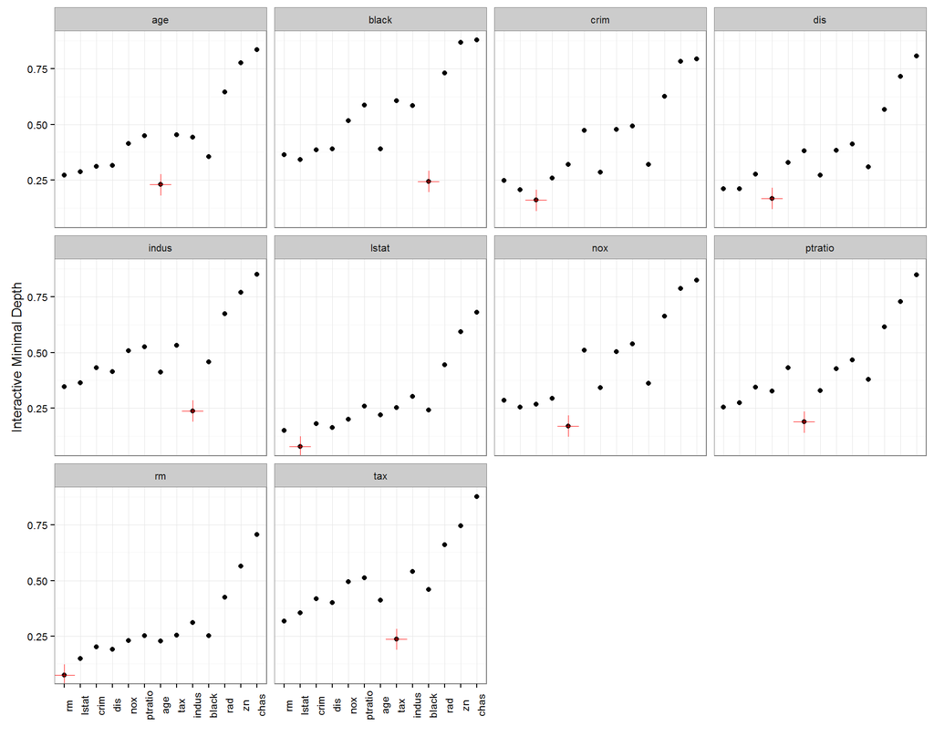

```r
plot(gg_interaction(interaction_Boston), xvar=xvar, panel = TRUE)
```

**Interpretacja:** podobnie jak dla zwyczajnego minimal depth szukamy małych wartości.

### Interakcje VIMP

W pakiecie `randomForestSRC` można również wyznaczyć miarę ważności interakcji opartą na VIMP, która nie jest wykorzystana w pakiecie `ggRandomForests`.

**Idea:** dla każdej pary zmiennych liczymy ich łączny VIMP (*paired* VIMP) oraz sumę ich indywidualnych VIMP (*additive* VIMP). Duże różnice między tymi dwoma miarami sugerują ważne interakcje (zaburzenie obu zmiennych naraz ma inny skutek niż zaburzenie tych zmiennych osobno).

```r
interaction_Boston <- find.interaction(rfsrc_Boston, importance = "permute", method = "vimp", sorted = TRUE)
```

[output not shown]

[output cut: 111 more lines]

```
## tax:age        3.5739  3.3444  6.8829   6.9183    -0.0355
## tax:rad        3.5739  1.1802  4.6664   4.7542    -0.0878
## tax:black      3.5739  1.0915  4.6105   4.6654    -0.0549
## tax:chas       3.5739  0.4194  3.9642   3.9933    -0.0292
## tax:zn         3.5739  0.3105  3.8621   3.8844    -0.0224
## age:rad        3.2516  1.1802  4.4635   4.4319     0.0316
## age:black      3.2516  1.0915  4.3945   4.3431     0.0513
## age:chas       3.2516  0.4194  3.6624   3.6710    -0.0086
## age:zn         3.2516  0.3105  3.5767   3.5621     0.0145
## rad:black      1.2450  1.0915  2.3329   2.3365    -0.0036
## rad:chas       1.2450  0.4194  1.6695   1.6644     0.0051
## rad:zn         1.2450  0.3105  1.5534   1.5555    -0.0021
## black:chas     1.0791  0.4194  1.5228   1.4985     0.0243
## black:zn       1.0791  0.3105  1.3888   1.3896    -0.0008
## chas:zn        0.4685  0.3105  0.7791   0.7790     0.0002
```

### Coplots

**Coplots** czyli *conditioning plots* służą do wizualizacji zależności prognozy od jednej zmiennej pod warunkiem drugiej (lub kilku innych). Obserwacje są grupowane według wartości zmiennych z warunku po czym dla każdej grupy rysujemy wykres *variable dependence*.

**Uwaga:** grupowanie najłatwiej przeprowadzić dla zmiennych jakościowych. Dla ilościowych, jak w tym przypadku, często trzeba grupować dość arbitralnie, np. według kwantyli.

W naszym przykładzie najbardziej interesująca jest interakcja między zmiennymi *lstat* i *rm*, wykres wygląda następująco:

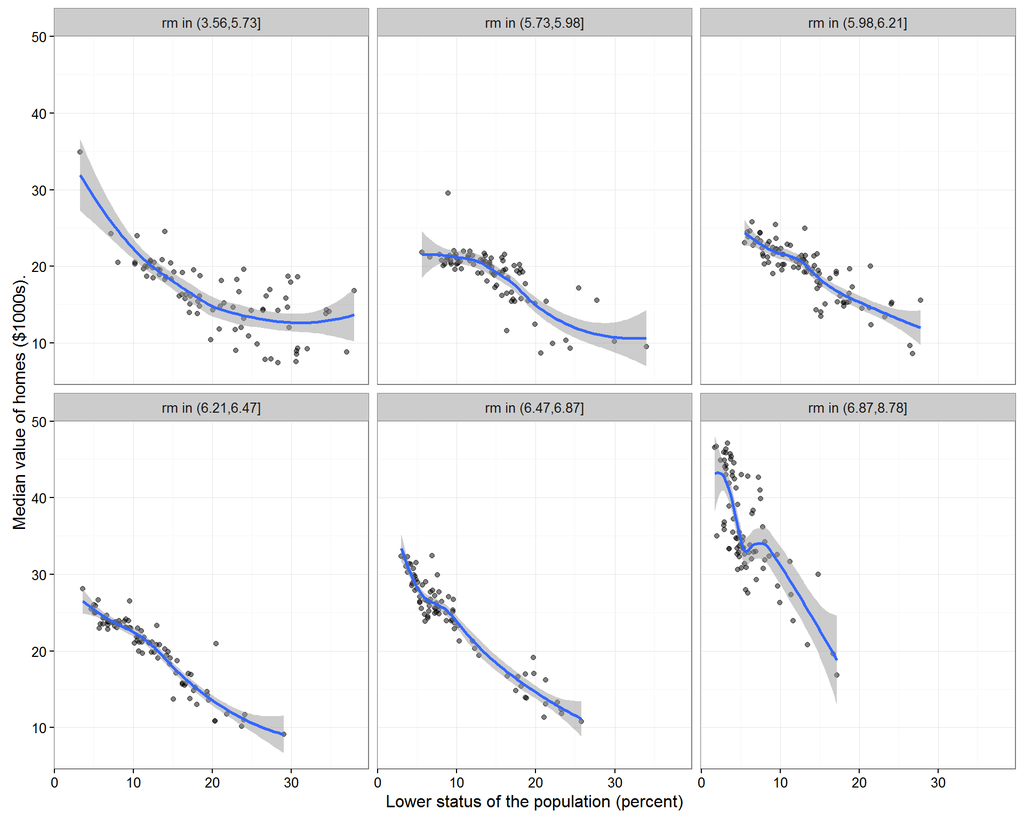

```r
rm_pts <- quantile_pts(rfsrc_Boston$xvar$rm, groups=6, intervals=TRUE) # cathegorize continuous variables
rm_grp <- cut(rfsrc_Boston$xvar$rm, breaks=rm_pts) # create 6 factor intervals
gg_v$rm_grp <- rm_grp # add the group factor to the gg_variable object
levels(gg_v$rm_grp) <- paste("rm in ", levels(gg_v$rm_grp), sep="") # modify labels
plot(gg_v, xvar = "lstat", smooth = TRUE, alpha = .5)+ geom_smooth(se=FALSE, span=1.5)+ labs(y = "Median value of homes ($1000s).", x="Lower status of the population (percent)")+ theme(legend.position = "none")+ facet_wrap(~rm_grp)
```

**Wniosek:** niezależnie od *rm* mediana ceny mieszkań maleje wraz ze wzrostem udziału w populacji osób o niskim statusie, przy czym zależność ta jest znacznie silniejsza dla większej średniej liczby pokoi w mieszkaniu.

## Podsumowanie

- Nie taki box czarny: dwie główne miary ważności zmiennych to minimal depth i variable importance, przy czym dla pierwszej z nich możemy obliczyć średnią co daje pewien punkt odniesienia.
- W dość przystępny sposób możemy badać dziesiątki interakcji między zmiennymi (wystarczy jeden wykres).
- Pakiet `ggRandomForests` dostarcza prostych funkcji generujących ładne wykresy w ggplocie.

## Bibliografia

- Ehrling, J., 2015. “ggRandomForests: Random Forests for Regression”
- Ishwaran, H., U. B. Kogular, E. Z. Gorodeski, A. J. Minn, M. S. Lauer, 2010. “High-dimensional variable selection for survival data”, *Journal of American Statistical Association*, 105, 205-217.
- dokumentacja pakietu `ggRandomForests`
- dokumentacja pakietu `randomForestSRC`